# Data Visualization Workshop

#### 2.2.4 Diverging colors

Diverging (cornea fold changes): map the log2 fold change of the genes that changed most after infection in cornea, using a diverging color scale. The goal is to understand which genes go up and which go down after infection. A positive value means the gene is higher in infected samples, while a negative value means it is lower. Zero (no change) is a meaningful middle point.

Diverging (USArrests dataset): map UrbanPop deviation from the median across states using a diverging color scale. The goal is to understand how each state’s urban population percentage compares to the median urban population percentage. A positive value means the state’s urban population is above the median, while a negative value means it is below the median.

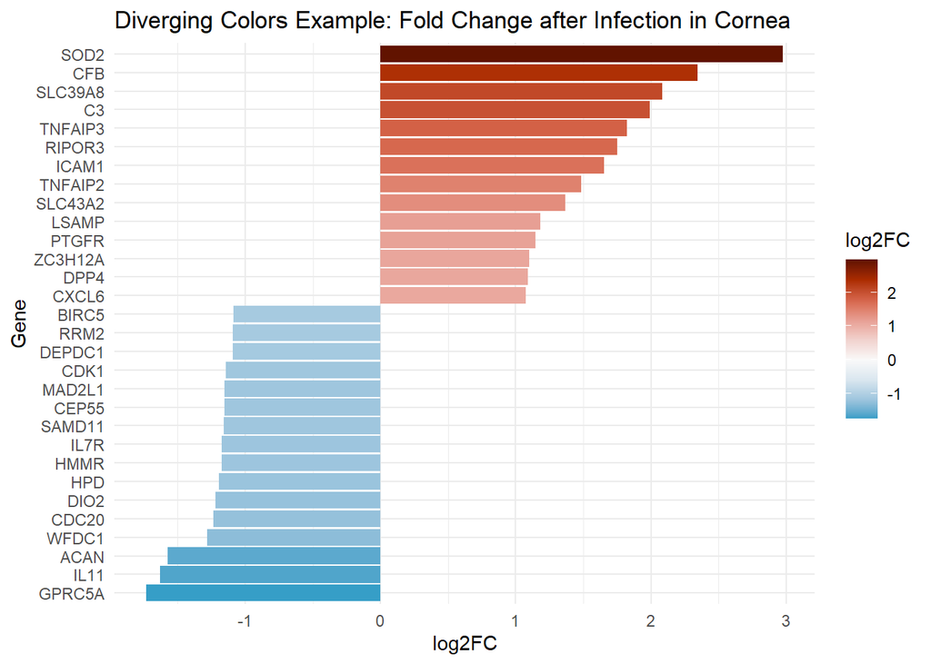

```r
# diverging colors (cornea fold changes)
# 30 genes with the largest change; avg_cpm >= 10 avoids noisy, barely expressed genes
cornea_fc <- gene_summary %>%
  filter(tissue == "cornea", avg_cpm >= 10) %>%
  slice_max(abs(log2FC), n = 30)

# Create a bar plot
ggplot(cornea_fc, aes(x = reorder(Gene, log2FC), y = log2FC, fill = log2FC)) +
  geom_bar(stat = "identity") +
  scale_fill_continuous_divergingx(palette = "RdBu", rev = TRUE) +  # rev: red = up, blue = down
  coord_flip() +
  xlab("Gene") +
  ggtitle("Diverging Colors Example: Fold Change after Infection in Cornea") +
  theme_minimal()
```

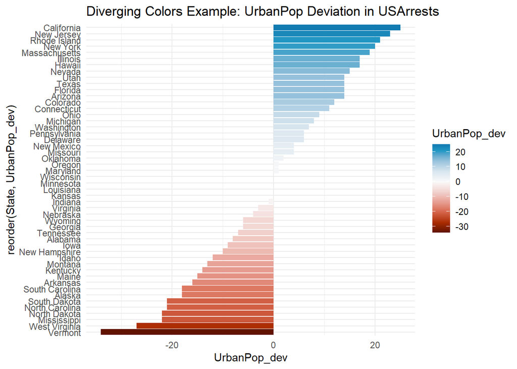

```r
# diverging colors (USArrest Dataset)
# Compute deviation from median
USArrests$State <- rownames(USArrests)
USArrests$UrbanPop_dev <- USArrests$UrbanPop - median(USArrests$UrbanPop)
# Create a bar plot
ggplot(USArrests, aes(x = reorder(State, UrbanPop_dev), y = UrbanPop_dev, fill = UrbanPop_dev)) +
  geom_bar(stat = "identity") +
  scale_fill_continuous_divergingx(palette = "RdBu") +
  coord_flip() +
  ggtitle("Diverging Colors Example: UrbanPop Deviation in USArrests") +
  theme_minimal()
```

### 2.3 Example 2

Compare the before-and-after heatmaps below to see how color choice enhance readability and perceptual accuracy in data visualization. The heatmap shows the mean expression of several inflammation-related genes in each tissue and condition.

#### 2.3.1 Before

Use the default color to create the heatmap.

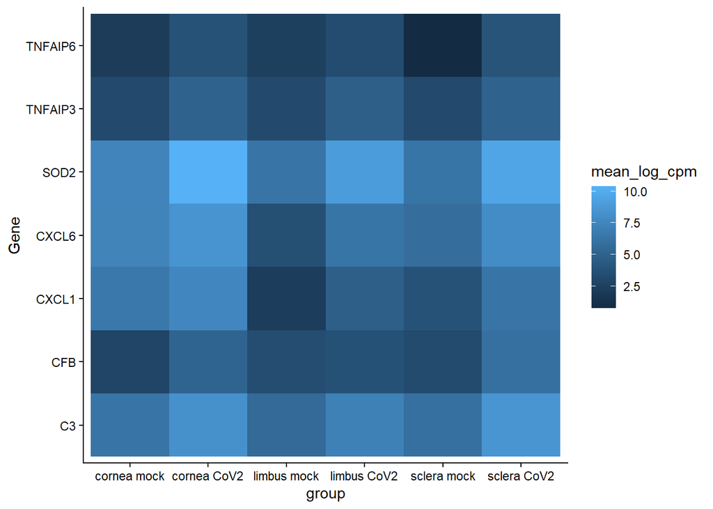

```r
# before
inflam_genes <- c("SOD2", "C3", "CXCL1", "CXCL6", "TNFAIP6", "CFB", "TNFAIP3")

expr %>%
  filter(Gene %in% inflam_genes) %>%
  group_by(group, Gene) %>%
  summarise(mean_log_cpm = mean(log_cpm), .groups = "drop") %>%
  ggplot(aes(x = group, y = Gene, fill = mean_log_cpm)) +
  geom_tile() +
  theme_classic()
```

#### 2.3.2 After

Use the Sequential color to show the heatmap.

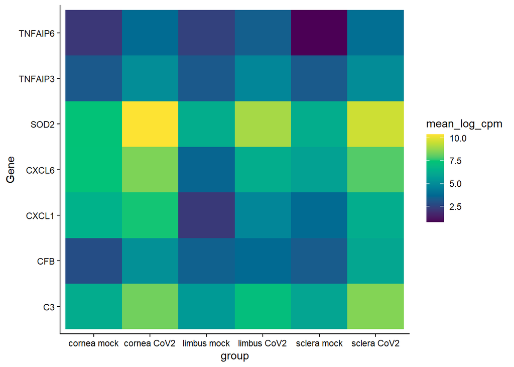

```r
# color choice 1 (Viridis)
expr %>%
  filter(Gene %in% inflam_genes) %>%
  group_by(group, Gene) %>%
  summarise(mean_log_cpm = mean(log_cpm), .groups = "drop") %>%
  ggplot(aes(x = group, y = Gene, fill = mean_log_cpm)) +
  geom_tile() +
  theme_classic() +
  scale_fill_continuous_sequential(palette = "Viridis", rev = FALSE)
```

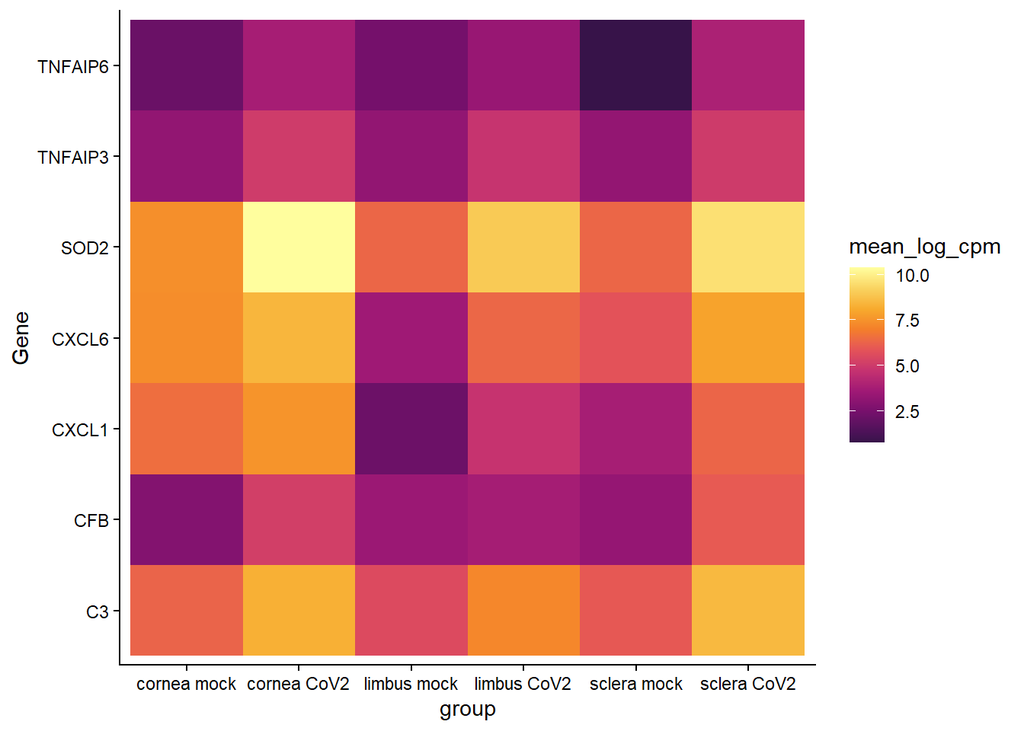

```r
# color choice 2 (Inferno)
expr %>%
  filter(Gene %in% inflam_genes) %>%
  group_by(group, Gene) %>%
  summarise(mean_log_cpm = mean(log_cpm), .groups = "drop") %>%
  ggplot(aes(x = group, y = Gene, fill = mean_log_cpm)) +
  geom_tile() +
  theme_classic() +
  scale_fill_continuous_sequential(palette = "Inferno", begin = 0.15, rev = FALSE)
```

### 2.4 Size & Transparency

Explore how to adjust the size and transparency of the points to enhance readability. Each point is one gene in one tissue, comparing its mean expression in mock (x) and infected (y) samples. When you have this many points (like about 40,000), size and transparency make a big difference.

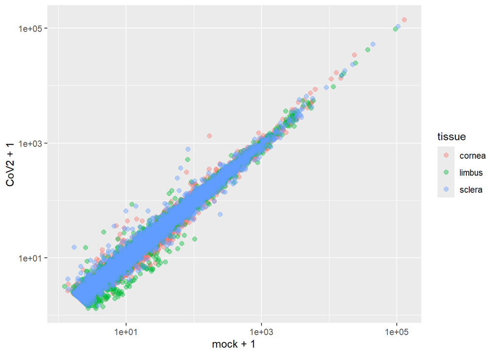

```r
ggplot(gene_summary) +
  geom_point(aes(x = mock + 1,
                 y = CoV2 + 1,
                 color = tissue),
             size = 2,
             alpha = 0.4) +
  scale_x_log10() +
  scale_y_log10()
```

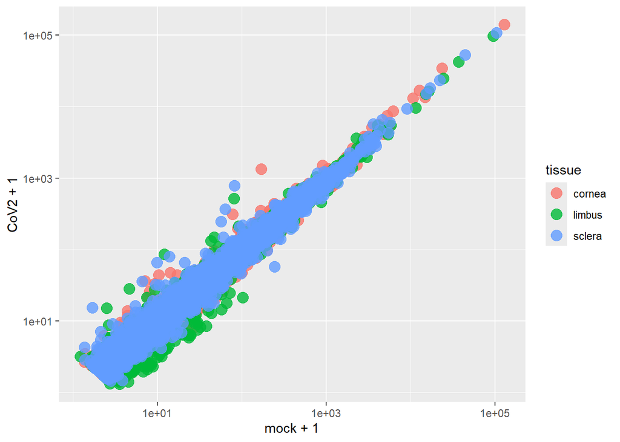

```r
ggplot(gene_summary) +
  geom_point(aes(x = mock + 1,
                 y = CoV2 + 1,
                 color = tissue),
             size = 4,
             alpha = 0.8) +
  scale_x_log10() +
  scale_y_log10()
```

### 2.5 Legend

The legend plays a crucial role in interpreting the plot. Below, we will explore how to adjust its appearance, create different legends for different layers, and learn how to delete or merge legends effectively.

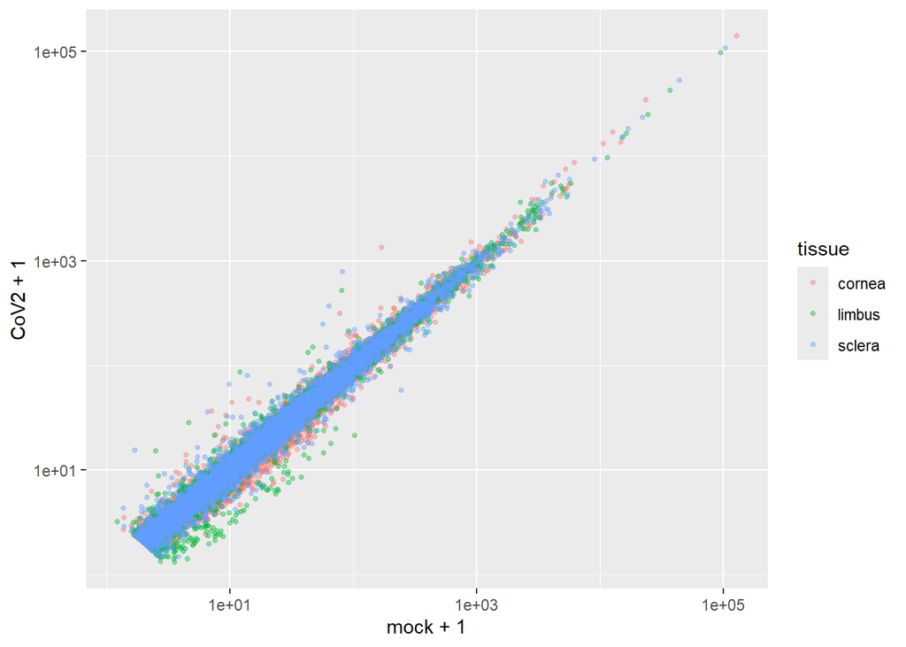

```r
ggplot(gene_summary, aes(x = mock + 1, y = CoV2 + 1, color = tissue)) +
  geom_point(size = 1, alpha = 0.4) +
  scale_x_log10() +
  scale_y_log10()
```

#### 2.5.1 Adjust the appearance of the legend

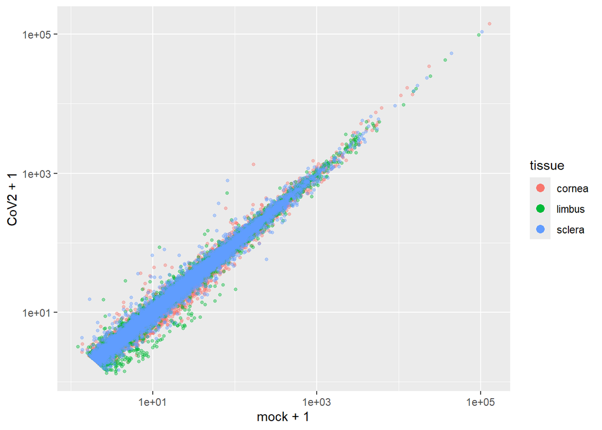

```r
# Adjust the appearance of the legend
ggplot(gene_summary, aes(x = mock + 1, y = CoV2 + 1, color = tissue)) +
  geom_point(size = 1, alpha = 0.4) +
  scale_x_log10() +
  scale_y_log10() +
  guides(color = guide_legend(override.aes = list(size = 3, alpha = 1)))
```

#### 2.5.2 Generate different legends for different layers

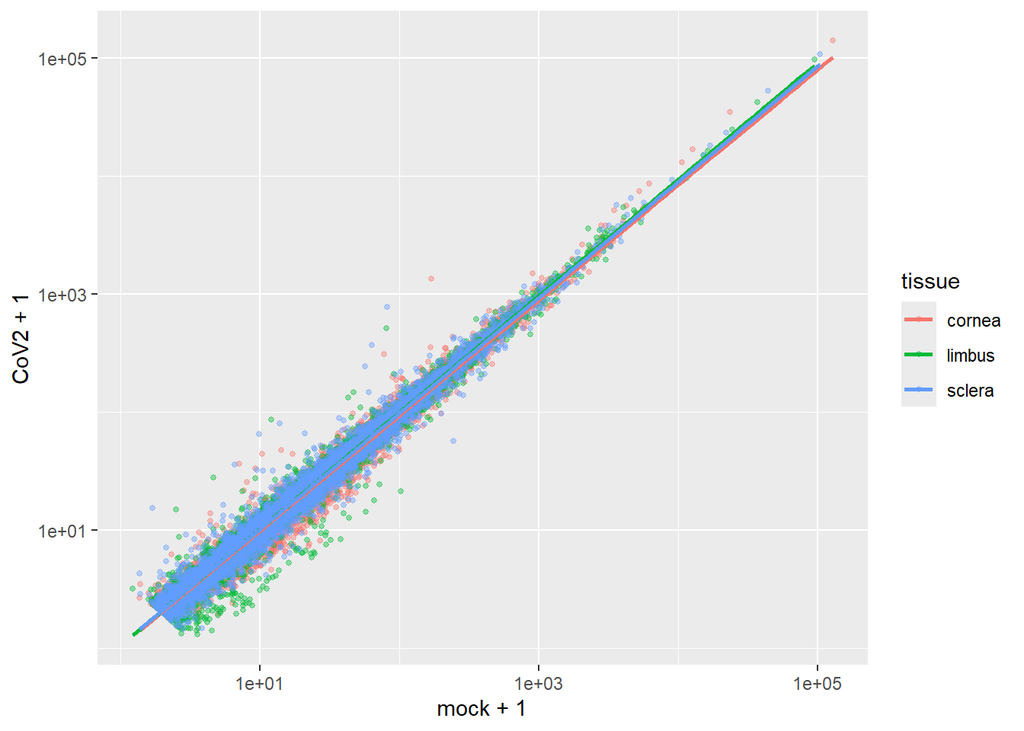

```r
# Generate different legends for different layers
ggplot(gene_summary, aes(x = mock + 1, y = CoV2 + 1, color = tissue)) +
  geom_point(size = 1, alpha = 0.4) +
  geom_smooth(method = "lm", se = FALSE) +
  scale_x_log10() +
  scale_y_log10()
```

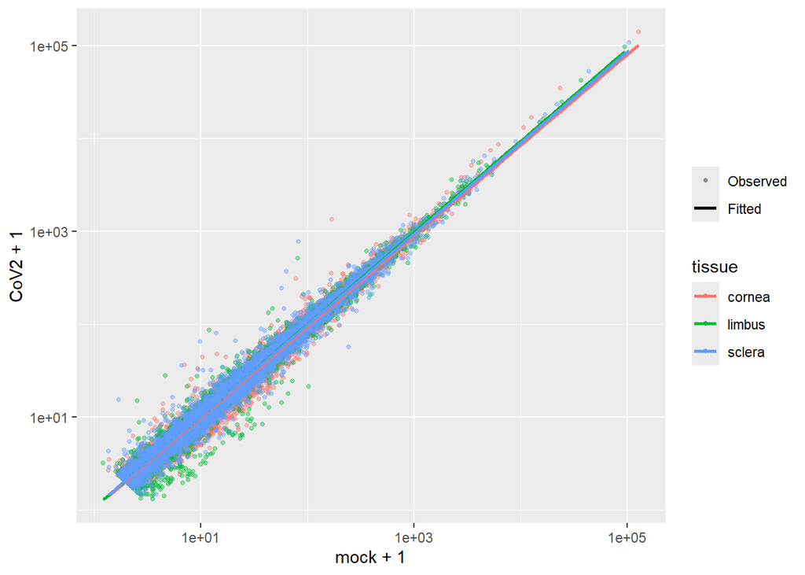

```r
ggplot(gene_summary, aes(x = mock + 1, y = CoV2 + 1, color = tissue)) +
  geom_point(aes(alpha = "Observed"), size = 1) +
  geom_smooth(method = "lm", se = FALSE, aes(alpha = "Fitted")) +
  scale_x_log10() +
  scale_y_log10() +
  scale_alpha_manual(
    name = NULL,
    values = c(Observed = 0.4, Fitted = 1),
    breaks = c("Observed", "Fitted")
  ) +
  guides(alpha = guide_legend(override.aes = list(
    linetype = c(0, 1),
    shape = c(16, NA),
    color = "black"
  )))
```

#### 2.5.3 Delete legend

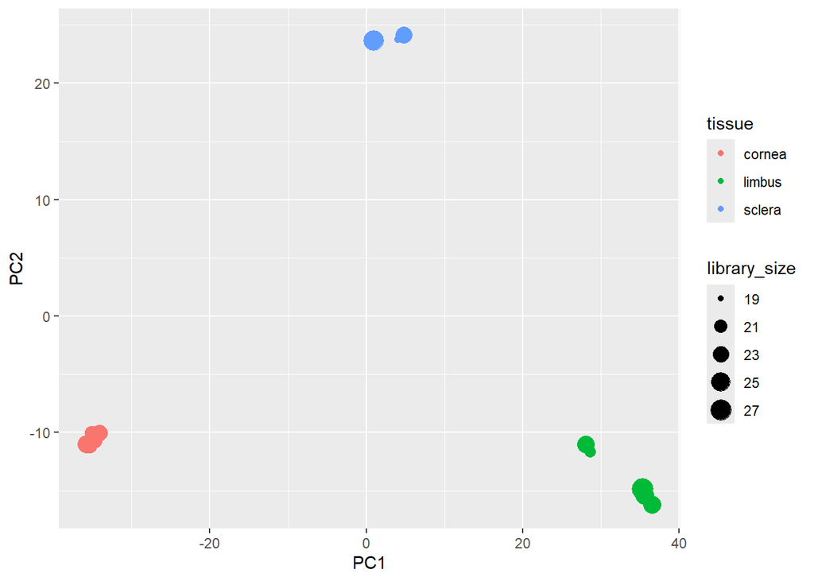

```r
# delete legend
pca_df %>%
  ggplot(aes(x = PC1, y = PC2, color = tissue, size = library_size)) +
  geom_point()
```

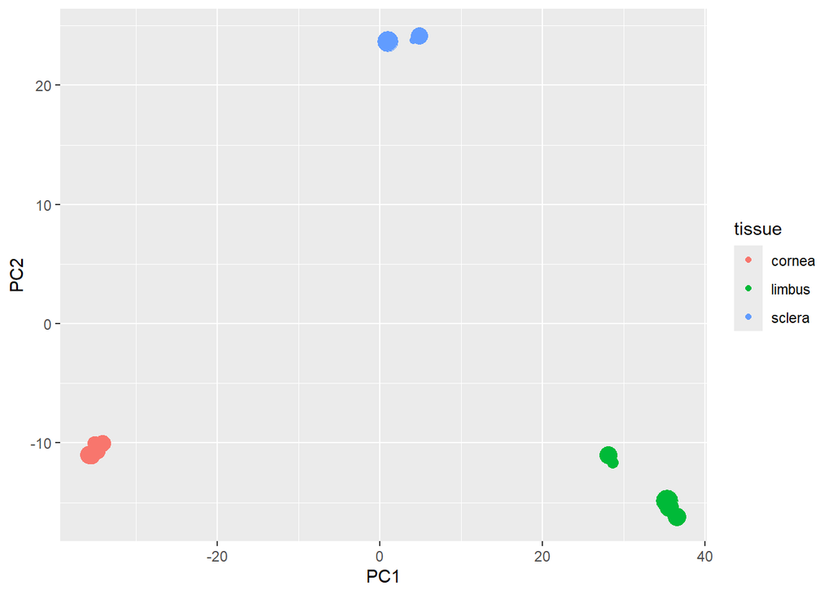

```r
pca_df %>%
  ggplot(aes(x = PC1, y = PC2, color = tissue, size = library_size)) +
  geom_point() +
  guides(
    color = guide_legend("tissue"),      # keep
    size = "none"                        # remove
  )
```

#### 2.5.4 Merge legend

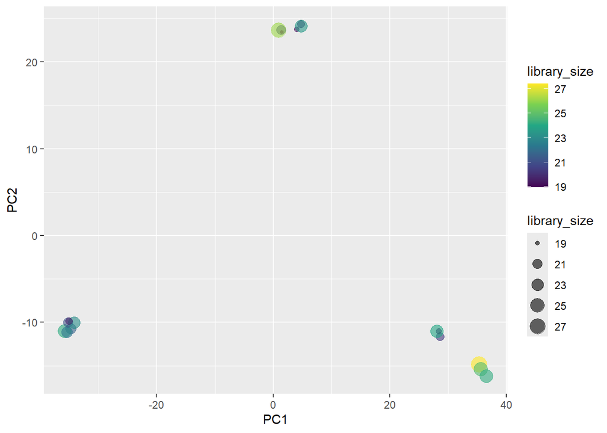

```r
# merge legend
pca_df %>%
  ggplot(
    aes(x = PC1, y = PC2,
      color = library_size, size = library_size)
  ) +
  geom_point(alpha = 0.6) +
  scale_color_viridis_c()
```

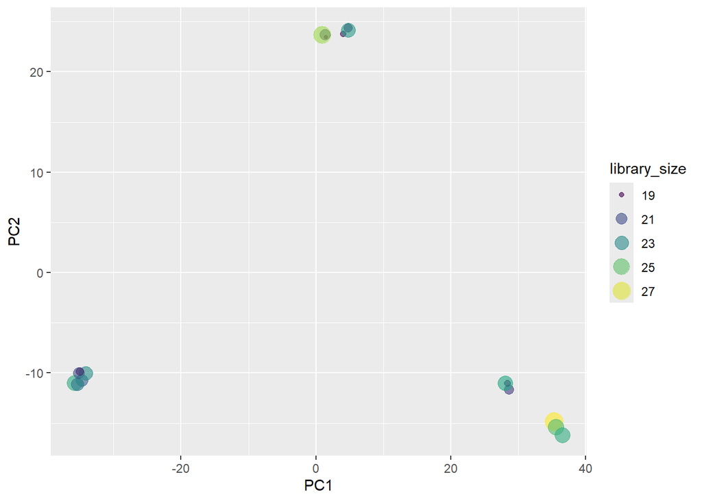

```r
# method 1
pca_df %>%
  ggplot(
    aes(x = PC1, y = PC2,
      color = library_size, size = library_size)
  ) +
  geom_point(alpha = 0.6) +
  scale_color_viridis_c() +
  guides(
    color = guide_legend(),
    size = guide_legend()
  )
```

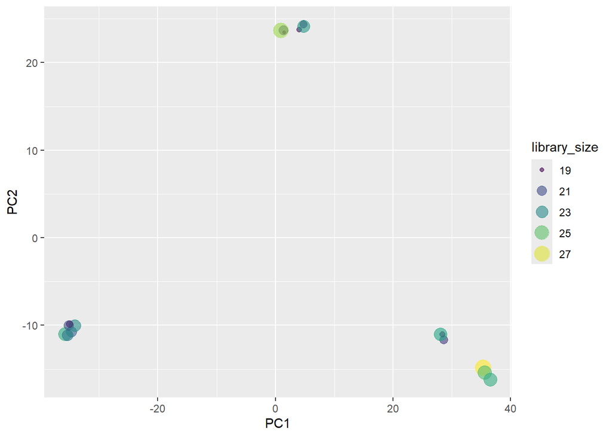

```r
# method 2
pca_df %>%
  ggplot(
    aes(x = PC1, y = PC2,
      color = library_size, size = library_size)
  ) +
  geom_point(alpha = 0.6) +
  scale_color_viridis_c(guide = "legend")
```

### 2.6 Theme

Explore how to change the theme of the plots.

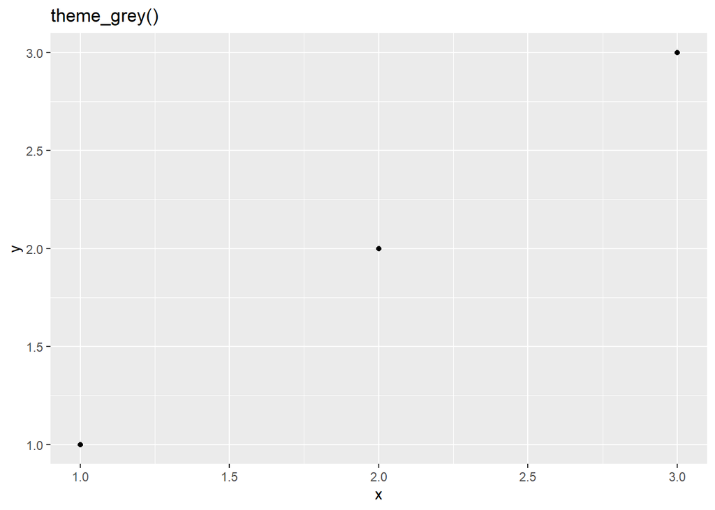

```r
df <- data.frame(x = 1:3, y = 1:3)
base <- ggplot(df, aes(x, y)) + geom_point()
# default theme
base + theme_grey() + ggtitle("theme_grey()")
```

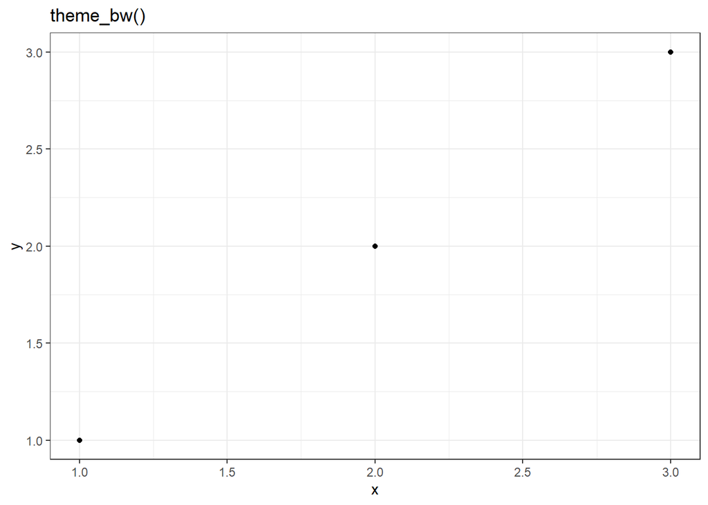

```r
# other built-in themes in ggplot2
base + theme_bw() + ggtitle("theme_bw()")
```

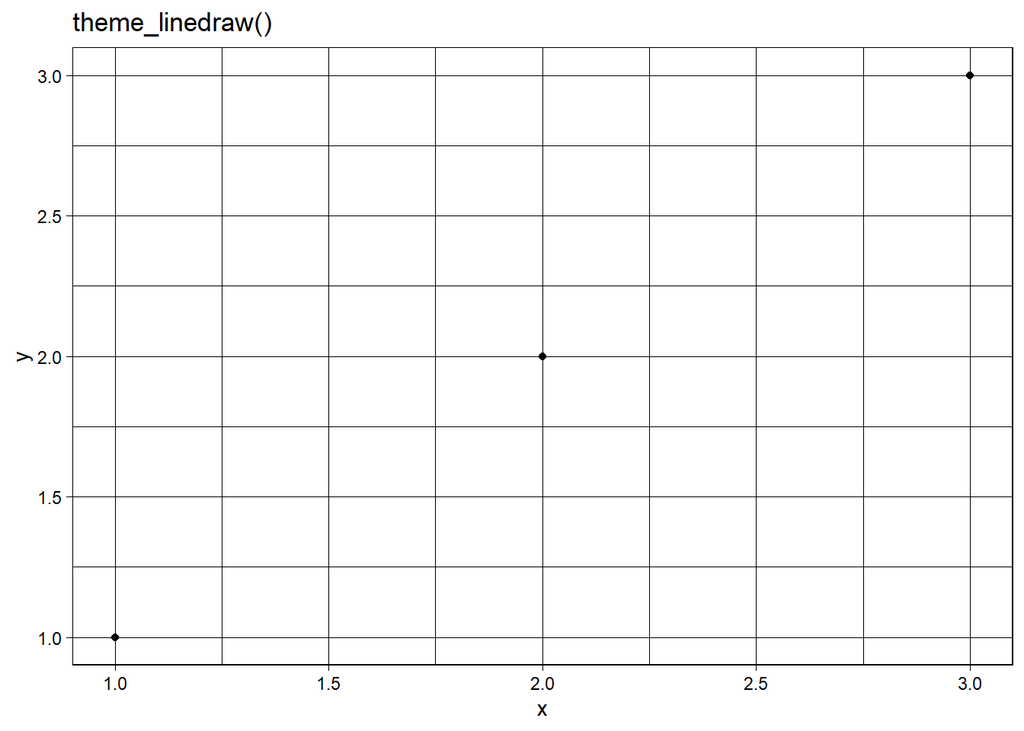

```r
base + theme_linedraw() + ggtitle("theme_linedraw()")
```

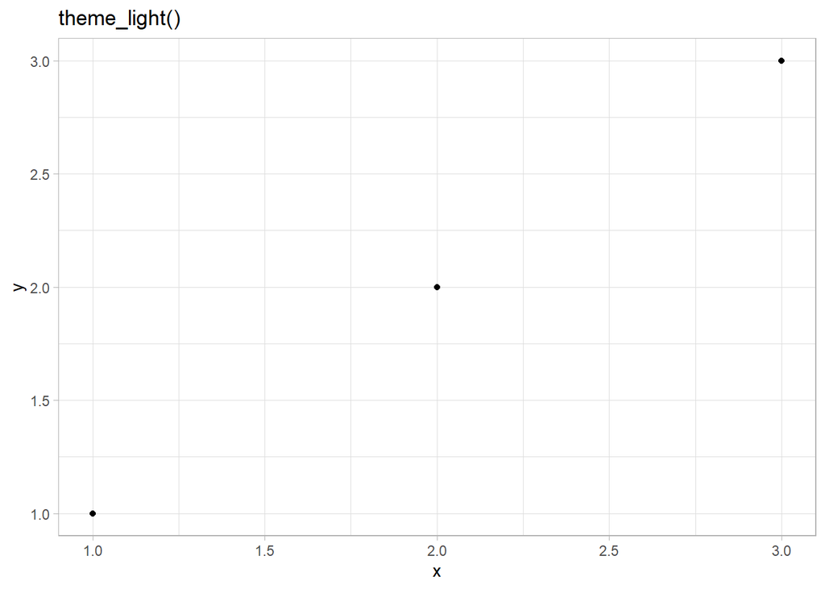

```r
base + theme_light() + ggtitle("theme_light()")
```

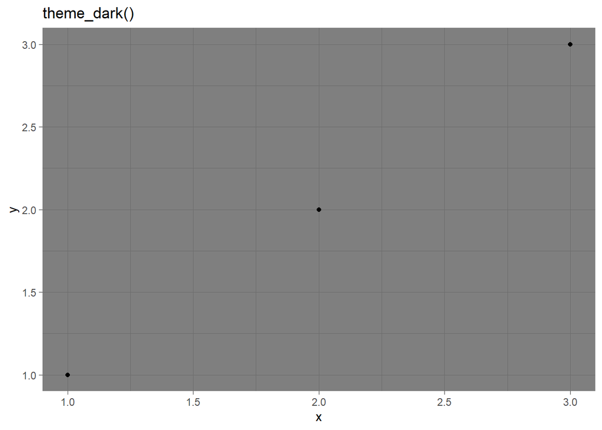

```r
base + theme_dark() + ggtitle("theme_dark()")
```

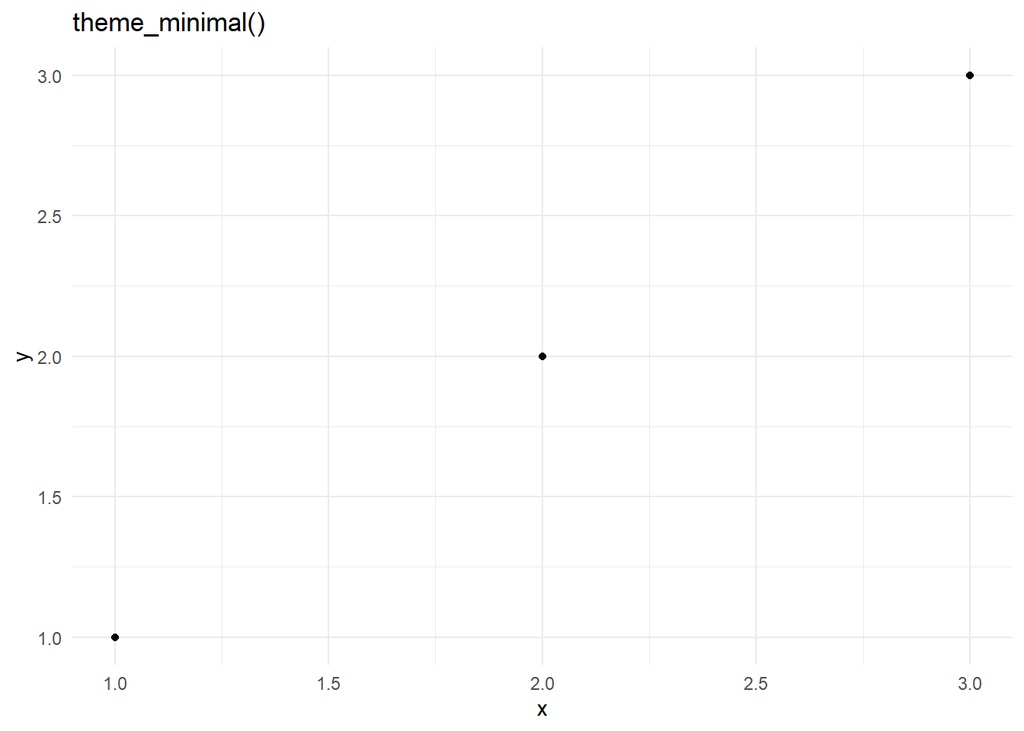

```r
base + theme_minimal()  + ggtitle("theme_minimal()")
```

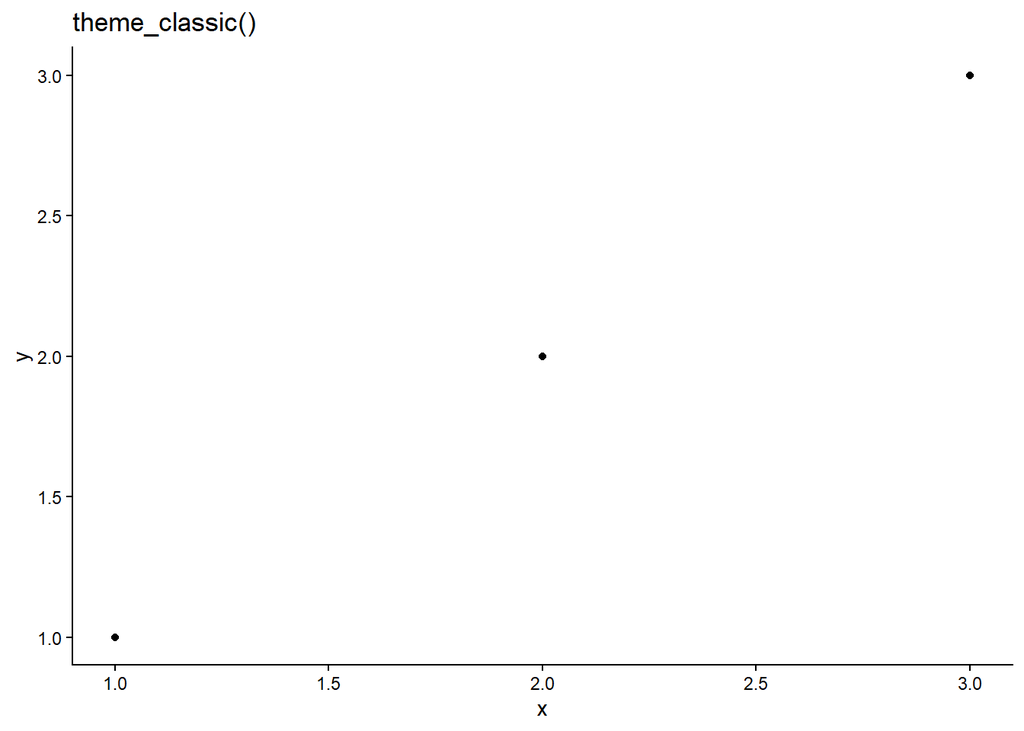

```r
base + theme_classic() + ggtitle("theme_classic()")
```

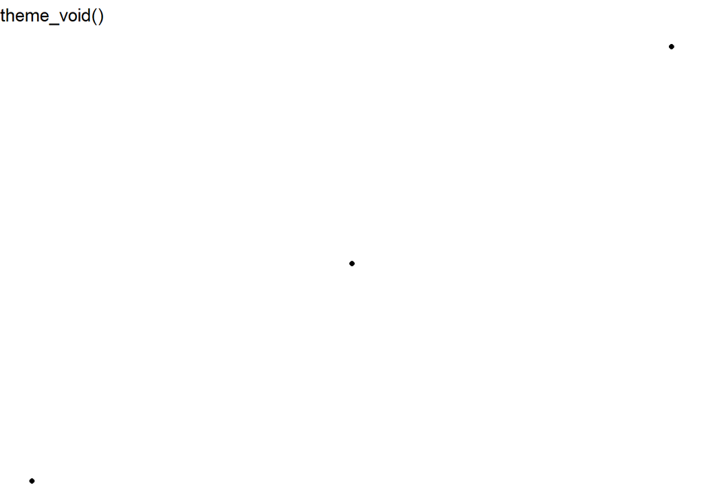

```r
base + theme_void() + ggtitle("theme_void()")
```

### 2.7 Exporting plots

Once a plot looks right, we usually want to save it as a file, for example to finish a figure in a graphic editor like Inkscape. There are two kinds of image formats:

- **Raster** formats (PNG, JPEG, TIFF) store the image as a grid of pixels. File size doesn’t depend on the number of points, but text and lines can’t be edited and the image gets blurry when enlarged.
- **Vector** formats (SVG, PDF) store every point as a separate shape. The text is sharp & editable but a plot with tens of thousands of points becomes a very large file that is slow to open and edit.

Our mock vs. infected scatter plot has about 40,000 points, so it is a good example of this problem.

```r
library(ggrastr)
```

```r
p_scatter <- ggplot(gene_summary, aes(x = mock + 1, y = CoV2 + 1, color = tissue)) +
  geom_point(size = 0.5, alpha = 0.4) +
  scale_x_log10() +
  scale_y_log10() +
  labs(x = "Mock (CPM + 1)", y = "SARS-CoV-2 (CPM + 1)") +
  theme_classic()

# raster: a fixed grid of pixels (dpi = dots per inch)
ggsave("scatter_raster.png", p_scatter, width = 6, height = 5, dpi = 300)

# vector: every one of the ~40,000 points is a separate shape
ggsave("scatter_vector.pdf", p_scatter, width = 6, height = 5)
```

#### 2.7.1 Rasterize only the points with ggrastr

The ggrastr package offers a middle ground: it rasterizes only the layers with many data points and keeps everything else (axes, text, legend) in vector format. Wrap the layer you want to rasterize in `rasterise()`:

```r
p_mixed <- ggplot(gene_summary, aes(x = mock + 1, y = CoV2 + 1, color = tissue)) +
  rasterise(geom_point(size = 0.5, alpha = 0.4), dpi = 300) +
  scale_x_log10() +
  scale_y_log10() +
  labs(x = "Mock (CPM + 1)", y = "SARS-CoV-2 (CPM + 1)") +
  theme_classic()

ggsave("scatter_mixed.pdf", p_mixed, width = 6, height = 5)

# compare file sizes in MB
file.size(c("scatter_raster.png", "scatter_vector.pdf", "scatter_mixed.pdf")) / 1e6
```

```
## [1] 0.282269 2.092735 0.300479
```

Alternatively, `rasterize()` can be applied to a finished plot, choosing layers by type:

```r
p_mixed2 <- rasterize(p_scatter, layers = "Point", dpi = 300)
```

When the mixed PDF is opened in Inkscape, the points appear as a single image that is quick to move and resize, and the axis labels, tick labels, and legend are still editable.

Some tips:

- `dpi = 300` is a common minimum for print figures. Higher resolution -> sharper image but larger file size
- To save as SVG instead of PDF, use a file name ending in `.svg` (this requires the svglite package); Inkscape opens both formats
- Set `width` and `height` in `ggsave()` to the size the figure will have in the final document (in inches by default), so that text sizes stay consistent and you don’t need to rescale the figure later

### 2.8 Exercise 1

Improve the plot based on the following requirements.

1. Improving the axes and legend labels
2. Adding a title for the plot
3. Tweaking the color scale to your favorite palette
4. The background should be white, not pale grey
5. Major gridlines should be a pale grey and minor gridlines should be removed
6. The plot title should be centered in 12pt bold text

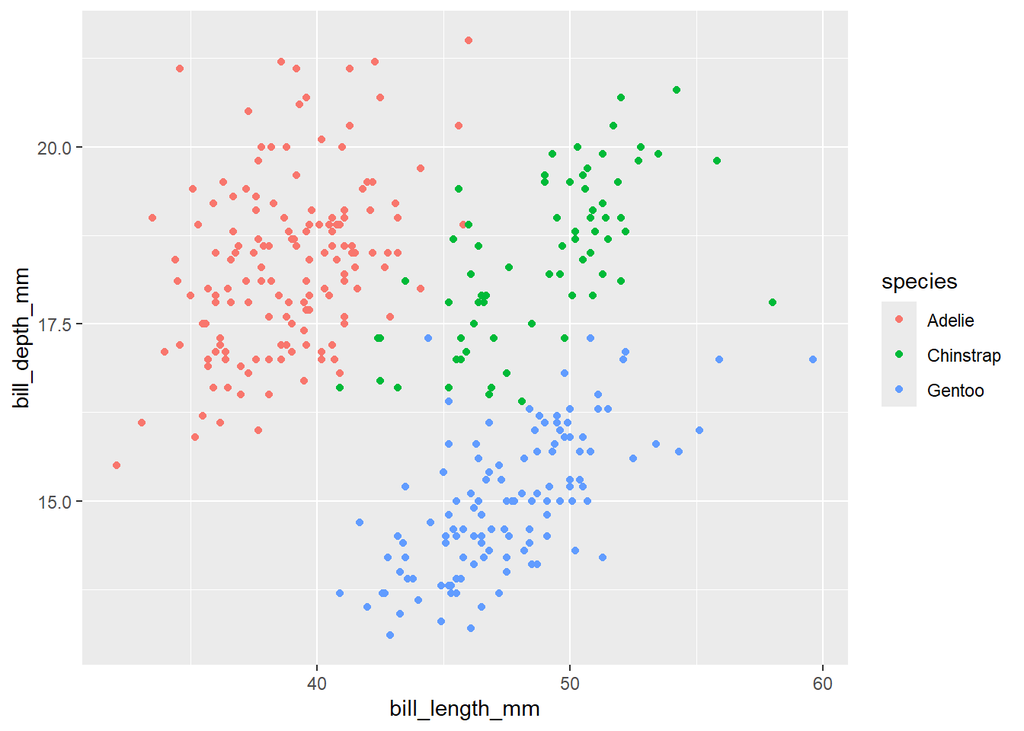

```r
ggplot(penguins, aes(x = bill_length_mm, y = bill_depth_mm, color = species)) +
  geom_point()
```

The answer is as follows. Do not open the answer code block before completing this exercise.

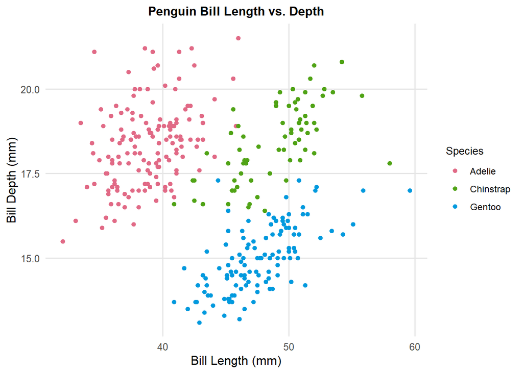

```r
# answer
ggplot(penguins, aes(x = bill_length_mm, y = bill_depth_mm, color = species)) +
  geom_point() +
  labs(
    title = "Penguin Bill Length vs. Depth",  # Add title
    x = "Bill Length (mm)",  # Improve x-axis label
    y = "Bill Depth (mm)",   # Improve y-axis label
    color = "Species"        # Improve legend label
  ) +
  scale_color_discrete_qualitative(palette = "Dark 3") + # Choose a favorite color palette
  theme_minimal(base_size = 12) +  # Set white background and base size
  theme(
    legend.justification = c(0.5, 0.5),  # Adjust legend positioning
    legend.title = element_text(size = 10),  # Set legend title font size
    legend.text = element_text(size = 9),   # Set legend text font size
    plot.title = element_text(size = 12, face = "bold", hjust = 0.5),  # Title centered in 12pt bold
    panel.grid.major = element_line(color = "grey90"),  # Pale grey major gridlines
    panel.grid.minor = element_blank(),  # Remove minor gridlines
    panel.background = element_blank()  # Set background to white
  )
```

## Module 3. Advanced Visualization Techniques

Next, we will explore some specialized plots and learn which types of data are best suited for each. To avoid version errors, if you’re using a new version of R and want to make sure, re-install these:

```r
install.packages("plotly")
install.packages("ggplot2")
```

Check for these libraries:

```r
library(tidyverse)
library(colorspace)
library(pheatmap)
library(plotly)
library(ggplot2)
library(gganimate)
library(gifski)
library(survival)
library(survminer)
library(qqman)
```

### 3.1 Specialized plot - heatmaps

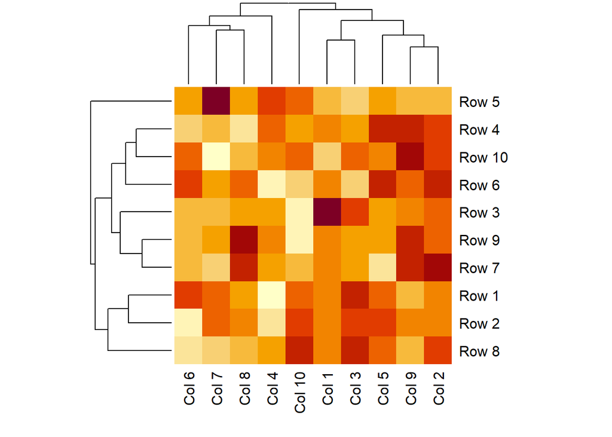

```r
# base R: heatmap() function
data <- matrix(rnorm(100), nrow = 10)
rownames(data) <- paste("Row", 1:10)
colnames(data) <- paste("Col", 1:10)
heatmap(data)
```

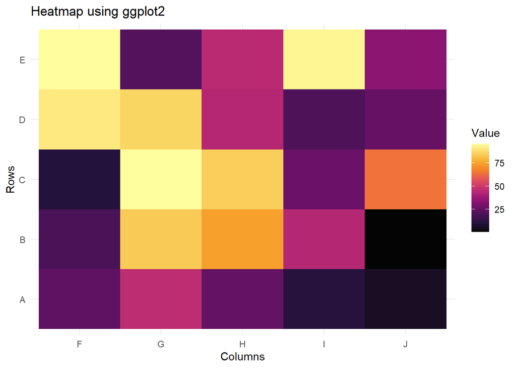

```r
# ggplot2 with geom_tile()
data <- expand.grid(Row = LETTERS[1:5], Column = LETTERS[6:10])
data$Value <- runif(nrow(data), 1, 100)
ggplot(data, aes(x = Column, y = Row, fill = Value)) +
  geom_tile() +
  scale_fill_continuous_sequential(palette = "Inferno", rev = FALSE) +
  labs(title = "Heatmap using ggplot2", x = "Columns", y = "Rows", fill = "Value") +
  theme_minimal()
```

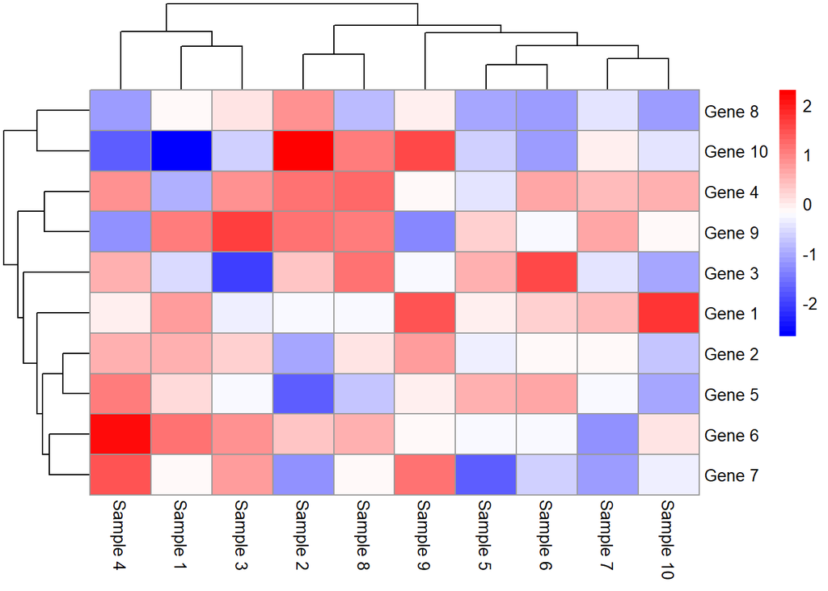

```r
# pheatmap for annotated heatmaps
data <- matrix(rnorm(100), nrow = 10)
rownames(data) <- paste("Gene", 1:10)
colnames(data) <- paste("Sample", 1:10)
pheatmap(data, color = colorRampPalette(c("blue", "white", "red"))(50))
```

### 3.2 Specialized plot - KM Curve

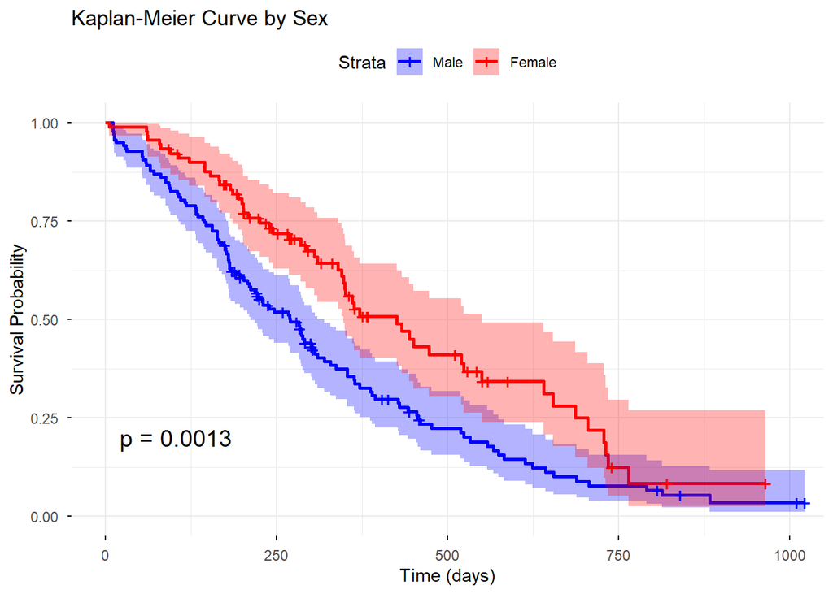

```r
# The 'lung' dataset is already loaded from the 'survival' library!

# Create a survival object
surv_object <- Surv(time = lung$time, event = lung$status)

# Fit a Kaplan-Meier survival curve by group
km_fit_group <- survfit(surv_object ~ sex, data = lung)

# Plot the Kaplan-Meier curves for groups
ggsurvplot(
  km_fit_group,
  data = lung,
  conf.int = TRUE,
  pval = TRUE,              # Add p-value from log-rank test
  xlab = "Time (days)",
  ylab = "Survival Probability",
  title = "Kaplan-Meier Curve by Sex",
  palette = c("blue", "red"), # Different colors for groups
  legend.labs = c("Male", "Female"), # Custom legend labels
  ggtheme = theme_minimal()
)
```

### 3.3 Specialized plot - Manhattan plot

```r
# Load the geuvadis dataset
data("gwasResults")

# Inspect the first few rows
head(gwasResults)
```

|  | SNP | CHR | BP | P |
| --- | --- | --- | --- | --- |
| 1 | rs1 | 1 | 1 | 0.9148060 |
| 2 | rs2 | 1 | 2 | 0.9370754 |
| 3 | rs3 | 1 | 3 | 0.2861395 |
| 4 | rs4 | 1 | 4 | 0.8304476 |
| 5 | rs5 | 1 | 5 | 0.6417455 |
| 6 | rs6 | 1 | 6 | 0.5190959 |

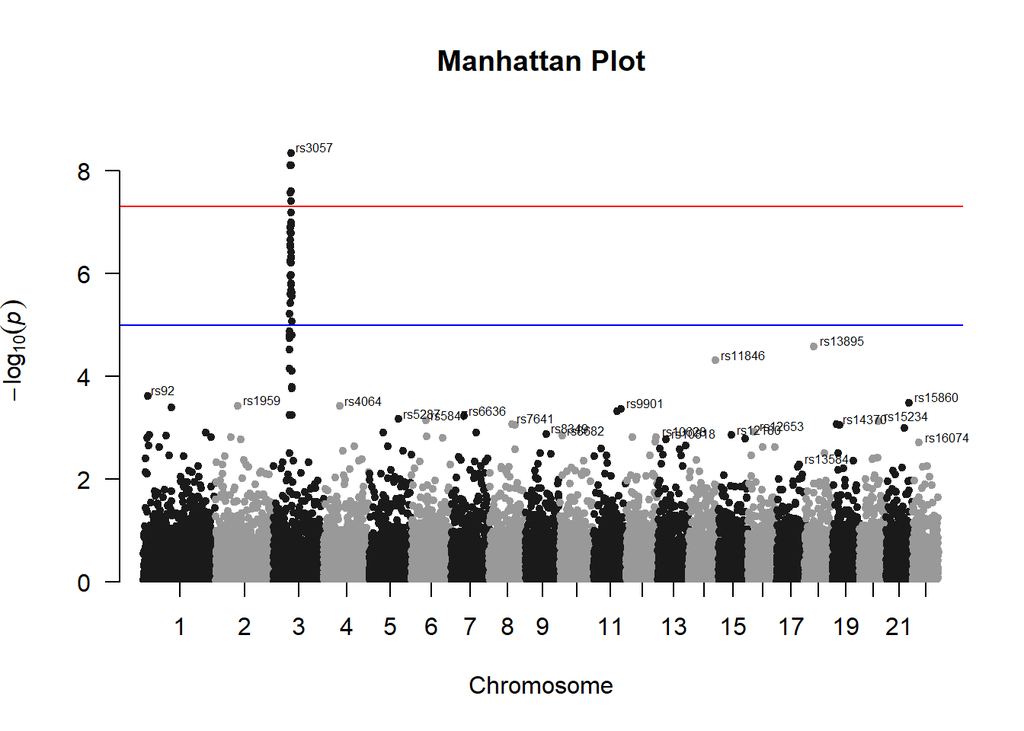

```r
# Structure of the data
# SNP: SNP identifier
# CHR: Chromosome
# BP: Base-pair position
# P: P-value

manhattan(
  gwasResults,
  chr = "CHR",       # Chromosome column
  bp = "BP",         # Base-pair position column
  p = "P",           # P-value column
  snp = "SNP",       # SNP column
  genomewideline = -log10(5e-8),  # Genome-wide significance threshold
  suggestiveline = -log10(1e-5),  # Suggestive significance threshold
  main = "Manhattan Plot", # Title
  annotatePval = 0.01
)
```

### 3.4 Specialized plot - 2d density plot

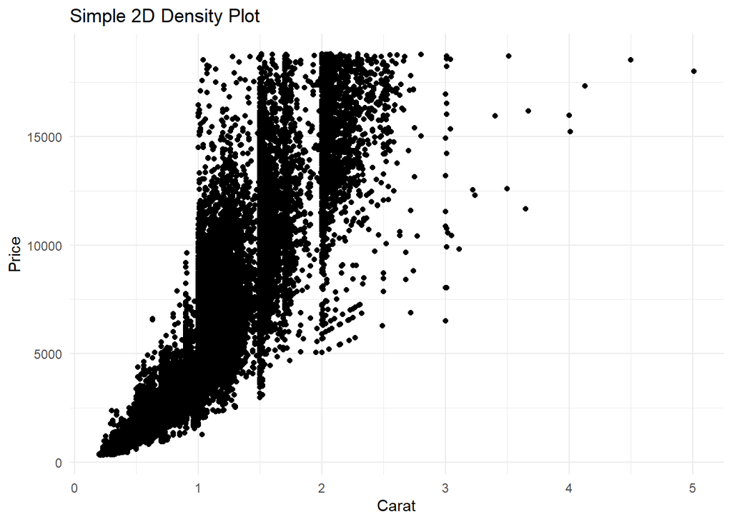

```r
# Scatter plot
ggplot(diamonds, aes(x = carat, y = price)) +
  geom_point() +
  theme_minimal() +
  labs(title = "Simple 2D Density Plot",
       x = "Carat",
       y = "Price")
```

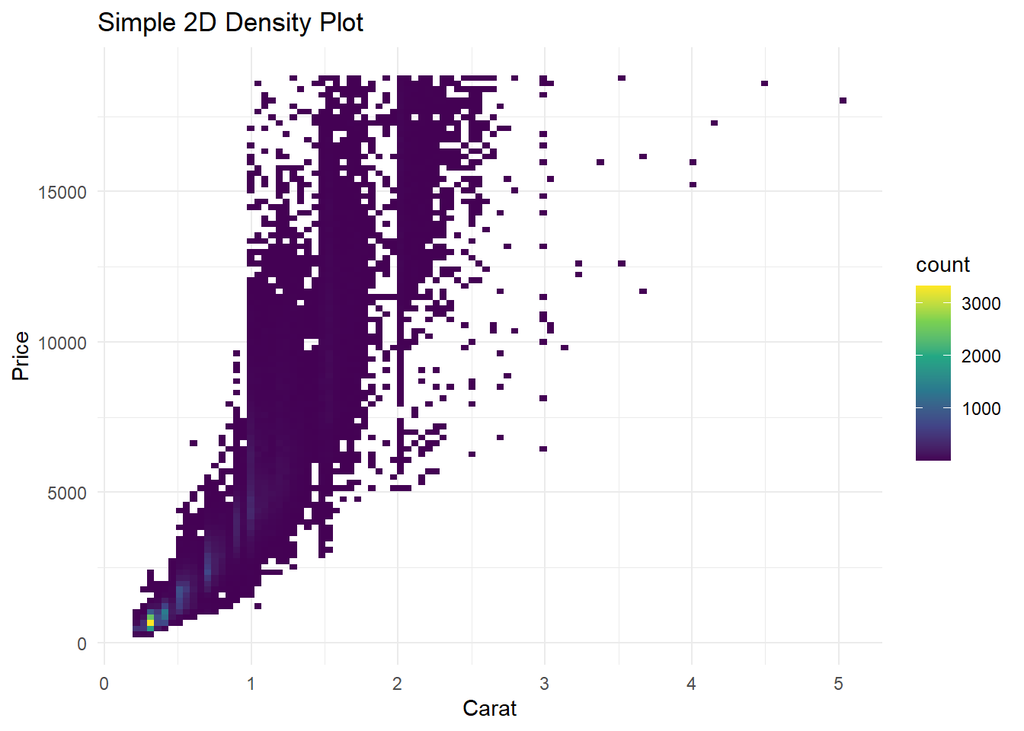

```r
# 2D density plot
ggplot(diamonds, aes(x = carat, y = price)) +
  geom_bin2d(bins = 100) +
  scale_fill_continuous(type = "viridis") +
  theme_minimal() +
  labs(title = "Simple 2D Density Plot",
       x = "Carat",
       y = "Price")
```

### 3.5 Interactive plot - plotly

Interactive plots allow users to explore data more deeply through actions like clicking, zooming, or hovering, providing richer insights and making the data more understandable and engaging. Next, we will explore how to make plots interactive.

#### 3.5.1 ggplotly

```r
p <- ggplot(penguins) +
  geom_point(aes(x = bill_length_mm,
                 y = bill_depth_mm,
                 color = species))

ggplotly(p)
```

[interactive chart not shown]

#### 3.5.2 Customize tooltip

What if we are interested in which island the penguin lives or any other information?

```r
penguins <- penguins %>%
  mutate(text = paste(
    "Island: ", island,
    "\nSpecies: ", species,
    "\nBill Length (mm): ", bill_length_mm,
    "\nBill Depth (mm): ", bill_depth_mm,
    "\nFlipper Length (mm): ",flipper_length_mm,
    "\nBody Mass (g): ", body_mass_g, sep=""
  ))
p <- ggplot(penguins) +
  geom_point(aes(x = bill_length_mm,
                 y = bill_depth_mm,
                 color = species,
                 text = text)) +
  theme(legend.position = "none")
ggplotly(p, tooltip="text")
```

[interactive chart not shown]

#### 3.5.3 More advanced customization

Adjust the tooltip based on the following requests.

1. Use bold text to make the tooltip more readable
2. Add a title to the tooltip
3. Change the background color of the tooltip to white
4. Change the font color of the tooltip to black

```r
penguins <- penguins %>%
  mutate(text = paste(
    "<span style='font-size:16px;'><b>", species, "</b></span><br>",
    "<br><b>Island:</b> ", island,
    "<br><b>Bill Length (mm):</b> ", bill_length_mm,
    "<br><b>Bill Depth (mm):</b> ", bill_depth_mm,
    "<br><b>Flipper Length (mm):</b> ",flipper_length_mm,
    "<br><b>Body Mass (g):</b> ", body_mass_g,
    sep=""
  ))
p <- ggplot(penguins) +
  geom_point(aes(x = bill_length_mm,
                 y = bill_depth_mm,
                 color = species,
                 text = text)) +
  theme(legend.position = "none")
pp <- ggplotly(p, tooltip="text")
pp <- pp %>%
  layout(
    hoverlabel = list(bgcolor = "white",
                      font = list(size = 12, color = "black"))
  )
pp
```

[interactive chart not shown]

### 3.6 Animated plot - gganimate

Using gganimate to create animated plots helps visualize changes over time, making it easier to understand dynamic patterns and trends in data. It adds an extra layer of clarity by showing how variables evolve, which can be especially useful for time-series data.

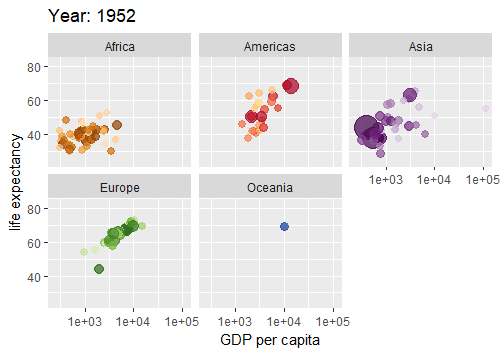

```r
# Create the plot
plot <- ggplot(gapminder, aes(gdpPercap, lifeExp, size = pop, colour = country)) +
  geom_point(alpha = 0.7, show.legend = FALSE) +
  scale_colour_manual(values = country_colors) +
  scale_size(range = c(2, 12)) +
  scale_x_log10() +
  facet_wrap(~continent) +
  # Here comes the gganimate specific bits
  labs(title = 'Year: {frame_time}', x = 'GDP per capita', y = 'life expectancy') +
  transition_time(year) +
  ease_aes('linear')

# Save at gif:
anim <- animate(plot, width = 500, height = 357, units = "px", res = 96, renderer = gifski_renderer())
anim_save("output.gif")
anim
```

### 3.7 Shiny app

Please open the “shiny app” folder.